# An Analysis on the Hong Kong Information and Communications Industry

### Author: Rowan Law

### Date: 20 June 2017

## Introduction

Hong Kong is well-known for its excellent infrastructure, stable power supply and relatively stable political environment. With the rise of the data-related industry, the Hong Kong Government is looking to promote the city as the regional hub for data centers. While at the same time, Hong Kong is also known for its lag in technological research and development.

With this in mind, we will look from the angle of employment in the Information and Communications (as "I&C" below) industry in Hong Kong. We will compare the employment evolution in the industry and that overall in Hong Kong from 2005 to 2015. We will also compare across Hong Kong and Japan to gain insights in the growth of the sector.

### Data source

We will source the data from the government statistics bureaus in HK and Japan:

1. HK Labour Force Data (source: Hong Kong Census and Statistics Department)
   - http://www.censtatd.gov.hk/hkstat/sub/sp200.jsp?tableID=006&ID=0&productType=8
2. HK Information and Communication Sector Employment Data (source: Hong Kong Census and Statistics Department)
   - http://www.censtatd.gov.hk/hkstat/sub/sp350.jsp?tableID=091&ID=0&productType=8
3. Japan Labour Force (source: Japan Statistics Bureau)
   - http://www.stat.go.jp/english/data/roudou/lngindex.htm
   - Historical Data 2
4. Japan Information and Communication Sector Employment Data (source: Japan Statistics Bureau)
   - http://www.stat.go.jp/english/data/roudou/lngindex.htm
   - Historical Data 5 (1)

First load the package and read in the data

```python
%matplotlib notebook
import pandas as pd
import matplotlib.pyplot as plt

HK_overall = pd.read_excel('HK_overall_employment.xlsx', skiprows = 1)
HK_IT = pd.read_excel('HK_IT_employment.xlsx', skiprows = 1)
JP_IT = pd.read_excel('Japan_employment.xlsx', skiprows = 6)
JP_overall = pd.read_excel('Japan_labour_force.xlsx', skiprows = 3)
```

## 1: Trimming the data to contain only useful rows and columns

We have read in the files. The next steps would be to extract the useful rows and columns, and clean the data accordingly.

### First file: Data for HK Labour Force

```python
HK_overall.head() #visualizing the raw data
```

|  | Period | Unnamed: 1 | Labour force | Unnamed: 3 | Unemployed ('000) | Unemployment rate (seasonally adjusted) (%) | Unemployment rate (not seasonally adjusted) (%) | Underemployed ('000) | Underemployment rate (%) |
| --- | --- | --- | --- | --- | --- | --- | --- | --- | --- |
| 0 | NaN | NaN | No. ('000) | Percentage change over the same period in prec... | NaN | NaN | NaN | NaN | NaN |
| 1 | 1982 | NaN | 2 498.1 | N.A. | 91.0 | - | 3.6 | N.A. | N.A. |
| 2 | 1983 | NaN | 2 540.5 | 1.7 | 113.8 | - | 4.5 | 47.2 | 1.9 |
| 3 | 1984 | NaN | 2 606.2 | 2.6 | 101.0 | - | 3.9 | 27.7 | 1.1 |
| 4 | 1985 | NaN | 2 626.9 | 0.8 | 83.6 | - | 3.2 | 49.4 | 1.9 |

From this file, we only keep the Labour Force figure, Unemployment figure and Unemployment Rate. We subset to only keep the target period 2005-2015.

```python
HK_overall = HK_overall.iloc[24:35,[0,2,4,6]]
HK_overall.columns = ['Year', 'HK Labour Force', 'HK Unemployed', 'HK Unemployment %']
```

There are inconsistent whitespaces in the data. We first convert the columns into strings, then remove the whitespaces, then convert back to integer, and lastly align data types (change headcount to integers). We also derive a new column "HK Employed" for overall employed population in HK.

```python
HK_overall['HK Labour Force'] = HK_overall['HK Labour Force'].apply(str)
HK_overall['HK Labour Force'] = pd.to_numeric(HK_overall['HK Labour Force'].str.replace(' ', ''), errors='coerce') * 1000
HK_overall['HK Labour Force'] = HK_overall['HK Labour Force'].astype(int)

HK_overall['HK Unemployed'] = HK_overall['HK Unemployed'].apply(str)
HK_overall['HK Unemployed'] = pd.to_numeric(HK_overall['HK Unemployed'].str.replace(' ', ''), errors='coerce') * 1000
HK_overall['HK Unemployed'] = HK_overall['HK Unemployed'].astype(int)

HK_overall['HK Employed'] = HK_overall['HK Labour Force'] - HK_overall['HK Unemployed']
```

```python
HK_overall.set_index('Year', inplace=True)
HK_overall = HK_overall[['HK Labour Force', 'HK Employed', 'HK Unemployed', 'HK Unemployment %']]
HK_overall #visualizing cleaned data
```

| Year | HK Labour Force | HK Employed | HK Unemployed | HK Unemployment % |
| --- | --- | --- | --- | --- |
| 2005 | 3534200 | 3336600 | 197600 | 5.6 |
| 2006 | 3571800 | 3400700 | 171100 | 4.8 |
| 2007 | 3622300 | 3477000 | 145300 | 4.0 |
| 2008 | 3637200 | 3509200 | 128000 | 3.5 |
| 2009 | 3660300 | 3467700 | 192600 | 5.3 |
| 2010 | 3631300 | 3474100 | 157200 | 4.3 |
| 2011 | 3703100 | 3576400 | 126700 | 3.4 |
| 2012 | 3782200 | 3657900 | 124300 | 3.3 |
| 2013 | 3855100 | 3724000 | 131100 | 3.4 |
| 2014 | 3871100 | 3743500 | 127600 | 3.3 |
| 2015 | 3903200 | 3773800 | 129400 | 3.3 |

### Second file: Data for HK Information and Communication industry employment

```python
HK_IT.head() #visualizing the raw data
```

|  | Major Industry Group | Year | Number of establishments | Number of persons engaged | Number of employees | Compensation of employees (HK$ million) | Operating expenses (HK$ million) (1) | Value of purchases of goods for sale (HK$ million) (2) | Business receipts and other income (HK$ million) | Value added (HK$ million) | Gross surplus (HK$ million) |
| --- | --- | --- | --- | --- | --- | --- | --- | --- | --- | --- | --- |
| 0 | Information and communications | 2005 | 7963 | 77021.0 | 74287.0 | 20876.0 | 57614.0 | 9493 | 109304.0 | 41615 | 19892 |
| 1 | NaN | 2006 | 7716 | 86346.0 | 82902.0 | 23206.0 | 59365.0 | 7351 | 114171.0 | 46687 | 22325 |
| 2 | NaN | 2007 | 7138 | 86241.0 | 82850.0 | 23490.0 | 66103.0 | 7263 | 125579.0 | 52410 | 28693 |
| 3 | NaN | 2008 | 6753 | 77075.0 | 75095.0 | 23302.0 | 73100.0 | 7085 | 128223.0 | 48061 | 24064 |
| 4 | NaN | 2009 | 7722 | 84292.0 | 81053.0 | 24610.0 | 63116.0 | 8737 | 118529.0 | 46897 | 22065 |

For this file, we keep the I&C Employment figure and I&C Compensation figure. We also subset to only keep the target period 2005-2015.

```python
HK_IT = HK_IT.iloc[:11, [1,4,5]]
HK_IT.columns = ['Year', 'HK I&C Employment', 'HK I&C Employee Compensation (HK$ million)']
HK_IT.iloc[:,:2] = HK_IT.iloc[:,:2].astype(int)
HK_IT.set_index('Year', inplace=True)
HK_IT #visualizing cleaned data
```

| Year | HK I&C Employment | HK I&C Employee Compensation (HK$ million) |
| --- | --- | --- |
| 2005 | 74287 | 20876.0 |
| 2006 | 82902 | 23206.0 |
| 2007 | 82850 | 23490.0 |
| 2008 | 75095 | 23302.0 |
| 2009 | 81053 | 24610.0 |
| 2010 | 88940 | 26942.0 |
| 2011 | 96336 | 31198.0 |
| 2012 | 94896 | 32567.0 |
| 2013 | 98713 | 36189.0 |
| 2014 | 102574 | 39339.0 |
| 2015 | 102499 | 38793.0 |

### Third File: Data for Japan Labour Force

```python
JP_overall.head() #visualizing the raw data
```

|  | Unnamed: 0 | Unnamed: 1 | (万人) | (Ten thousand persons) | Unnamed: 4 | Unnamed: 5 | Unnamed: 6 | Unnamed: 7 | Unnamed: 8 | Unnamed: 9 | ... | Unnamed: 30 | Unnamed: 31 | Unnamed: 32 | Unnamed: 33 | Unnamed: 34 | Unnamed: 35 | Unnamed: 36 | Unnamed: 37 | Unnamed: 38 | Unnamed: 39 |
| --- | --- | --- | --- | --- | --- | --- | --- | --- | --- | --- | --- | --- | --- | --- | --- | --- | --- | --- | --- | --- | --- |
| 0 | NaN | NaN | 男女計 | Both sexes | NaN | NaN | NaN | NaN | NaN | NaN | ... | NaN | NaN | NaN | NaN | NaN | NaN | NaN | NaN | NaN | NaN |
| 1 | 年次 | NaN | 15歳以上人口 | 労働力人口 | Labour force | NaN | 非労働力人口 | Not in labour force | NaN | NaN | ... | NaN | NaN | 労働力人口\n比率（％） | 就業率\n（％） | 完全失業率 （％） | NaN | NaN | NaN | NaN |  |
| 2 | NaN | NaN | Population aged 15 years old and over | 総数 | NaN | NaN | 総数 | NaN | NaN | NaN | ... | NaN | NaN | NaN | NaN | NaN | NaN | NaN | NaN | NaN | NaN |
| 3 | Year | NaN | NaN | Total | 就業者 | 完全失業者 | Total | 通学 | 家事 | その他 | ... | 家事 | その他 | NaN | NaN | NaN | NaN | NaN | NaN | NaN | NaN |
| 4 | NaN | NaN | NaN | NaN | Employed\nperson | Unemployed person | NaN | Attending school | House Keeping | Other | ... | House Keeping | Other | Labour force participation rate (Percent) | Employment rate (Percent) | Unemployment rate (Percent) | NaN | NaN | NaN | NaN | NaN |

5 rows × 40 columns

Similarly, for the Japan datasets, we select useful columns (Year and Japan Labour Force) and rows (2005-2015), amend columns names and align data types.

```python
JP_overall = JP_overall.iloc[59:70, [1,3]]
JP_overall = JP_overall.astype(int)
JP_overall.columns = ['Year', 'JP Labour Force']

JP_overall.set_index('Year', inplace=True)
JP_overall['JP Labour Force'] = JP_overall['JP Labour Force'] * 10000
JP_overall #visualizing cleaned data
```

| Year | JP Labour Force |
| --- | --- |
| 2005 | 66510000 |
| 2006 | 66640000 |
| 2007 | 66840000 |
| 2008 | 66740000 |
| 2009 | 66500000 |
| 2010 | 66320000 |
| 2011 | 65960000 |
| 2012 | 65650000 |
| 2013 | 65930000 |
| 2014 | 66090000 |
| 2015 | 66250000 |

### Fourth file: Data for Japan Information and Communication industry employment

```python
JP_IT.head() #visualizing the raw data
```

|  | Year | Unnamed: 1 | Total | Agriculture and forestry | Non-agricultural industries | 漁業 | 鉱業，採石業，砂利採取業 | 建設業 | 製造業 | 電気・ガス・熱供給・水道業 | ... | 金融業，保険業.2 | 不動産業，物品賃貸業.2 | 学術研究，専門・技術サービス業.2 | 宿泊業，飲食サービス業.2 | 生活関連サービス業，娯楽業.2 | 教育，学習支援業.2 | 医療，福祉.2 | 複合サービス事業.2 | サービス業（他に分類されないもの）.2 | 公務（他に分類されるものを除く）.2 |
| --- | --- | --- | --- | --- | --- | --- | --- | --- | --- | --- | --- | --- | --- | --- | --- | --- | --- | --- | --- | --- | --- |
| 0 | NaN | NaN | NaN | NaN | NaN | Fisheries | Mining and quarrying of stone and gravel | Construction | Manufacturing | Electricity, gas, heat supply and water | ... | Finance and insurance | Real estate and goods rental and leasing | Scientific research, professional and technica... | Accommodations, eating and drinking services | Living-related and personal services and amuse... | Education, learning support | Medical, health care and welfare | Compound services | Services, N.E.C. | Government, except elsewhere classified |
| 1 | NaN | NaN | NaN | NaN | NaN | NaN | NaN | NaN | NaN | NaN | ... | NaN | NaN | NaN | NaN | NaN | NaN | NaN | NaN | NaN | NaN |
| 2 | 平成14年 | 2002.0 | 6330 | 268.0 | 6063.0 | 28 | 5 | 618 | 1202 | 34 | ... | 86 | 38 | 68 | 240 | 145 | 148 | 362 | 25 | 151 | 47 |
| 3 | 15 | 2003.0 | 6316 | 266.0 | 6050.0 | 27 | 5 | 604 | 1178 | 32 | ... | 80 | 36 | 67 | 236 | 143 | 145 | 386 | 26 | 158 | 47 |
| 4 | 16 | 2004.0 | 6329 | 264.0 | 6064.0 | 22 | 4 | 584 | 1150 | 31 | ... | 81 | 36 | 68 | 234 | 141 | 148 | 408 | 28 | 170 | 48 |

5 rows × 65 columns

For the Japan I&C data, we select the I&C Industry Employment figures and rows (2005-2015), amend columns names and convert headcount data type to integers.

```python
JP_IT = JP_IT.iloc[5:16,[1,10]]
JP_IT.columns = ['Year', 'JP I&C Employment']
JP_IT= JP_IT.astype(int)
JP_IT.set_index('Year', inplace=True)
JP_IT = JP_IT * 10000
```

```python
JP_IT #visualizing cleaned data
```

| Year | JP I&C Employment |
| --- | --- |
| 2005 | 1750000 |
| 2006 | 1800000 |
| 2007 | 1920000 |
| 2008 | 1900000 |
| 2009 | 1940000 |
| 2010 | 1970000 |
| 2011 | 1910000 |
| 2012 | 1880000 |
| 2013 | 1920000 |
| 2014 | 2040000 |
| 2015 | 2090000 |

We then combine the 4 datasets with year as index. With the merged dataset, we derive more columns for later plot charting.

```python
full_data = pd.merge(HK_overall, HK_IT, how = 'inner', left_index = True, right_index = True)
full_data = pd.merge(full_data, JP_overall, how = 'inner', left_index = True, right_index = True)
full_data = pd.merge(full_data, JP_IT, how = 'inner', left_index = True, right_index = True)

full_data
```

| Year | HK Labour Force | HK Employed | HK Unemployed | HK Unemployment % | HK I&C Employment | HK I&C Employee Compensation (HK$ million) | JP Labour Force | JP I&C Employment |
| --- | --- | --- | --- | --- | --- | --- | --- | --- |
| 2005 | 3534200 | 3336600 | 197600 | 5.6 | 74287 | 20876.0 | 66510000 | 1750000 |
| 2006 | 3571800 | 3400700 | 171100 | 4.8 | 82902 | 23206.0 | 66640000 | 1800000 |
| 2007 | 3622300 | 3477000 | 145300 | 4.0 | 82850 | 23490.0 | 66840000 | 1920000 |
| 2008 | 3637200 | 3509200 | 128000 | 3.5 | 75095 | 23302.0 | 66740000 | 1900000 |
| 2009 | 3660300 | 3467700 | 192600 | 5.3 | 81053 | 24610.0 | 66500000 | 1940000 |
| 2010 | 3631300 | 3474100 | 157200 | 4.3 | 88940 | 26942.0 | 66320000 | 1970000 |
| 2011 | 3703100 | 3576400 | 126700 | 3.4 | 96336 | 31198.0 | 65960000 | 1910000 |
| 2012 | 3782200 | 3657900 | 124300 | 3.3 | 94896 | 32567.0 | 65650000 | 1880000 |
| 2013 | 3855100 | 3724000 | 131100 | 3.4 | 98713 | 36189.0 | 65930000 | 1920000 |
| 2014 | 3871100 | 3743500 | 127600 | 3.3 | 102574 | 39339.0 | 66090000 | 2040000 |
| 2015 | 3903200 | 3773800 | 129400 | 3.3 | 102499 | 38793.0 | 66250000 | 2090000 |

```python
full_data['Ratio of HK I&C Population'] = full_data['HK I&C Employment'] / full_data['HK Labour Force'] * 100
full_data['Ratio of JP I&C Population'] = full_data['JP I&C Employment'] / full_data['JP Labour Force'] * 100
full_data['HK I&C Employee Compensation (per head)'] = full_data['HK I&C Employee Compensation (HK$ million)'] * 10**6 / full_data['HK I&C Employment']
full_data['HK Non-I&C Employment'] = full_data['HK Employed'] - full_data['HK I&C Employment']
full_data['HK I&C Employment Change %'] = (full_data['HK I&C Employment'] - full_data['HK I&C Employment'].shift(1))/full_data['HK I&C Employment'].shift(1) * 100
full_data['HK Employment Change %'] = (full_data['HK Employed'] - full_data['HK Employed'].shift(1))/full_data['HK Employed'].shift(1) * 100

full_data = full_data.iloc[:,[0,1,2,13,3,4,11,8,12,5,10,6,7,9]]

full_data
```

| Year | HK Labour Force | HK Employed | HK Unemployed | HK Employment Change % | HK Unemployment % | HK I&C Employment | HK Non-I&C Employment | Ratio of HK I&C Population | HK I&C Employment Change % | HK I&C Employee Compensation (HK$ million) | HK I&C Employee Compensation (per head) | JP Labour Force | JP I&C Employment | Ratio of JP I&C Population |
| --- | --- | --- | --- | --- | --- | --- | --- | --- | --- | --- | --- | --- | --- | --- |
| 2005 | 3534200 | 3336600 | 197600 | NaN | 5.6 | 74287 | 3262313 | 2.101947 | NaN | 20876.0 | 281018.213146 | 66510000 | 1750000 | 2.631183 |
| 2006 | 3571800 | 3400700 | 171100 | 1.921117 | 4.8 | 82902 | 3317798 | 2.321015 | 11.596915 | 23206.0 | 279920.870425 | 66640000 | 1800000 | 2.701080 |
| 2007 | 3622300 | 3477000 | 145300 | 2.243656 | 4.0 | 82850 | 3394150 | 2.287221 | -0.062725 | 23490.0 | 283524.441762 | 66840000 | 1920000 | 2.872531 |
| 2008 | 3637200 | 3509200 | 128000 | 0.926086 | 3.5 | 75095 | 3434105 | 2.064638 | -9.360290 | 23302.0 | 310300.286304 | 66740000 | 1900000 | 2.846868 |
| 2009 | 3660300 | 3467700 | 192600 | -1.182606 | 5.3 | 81053 | 3386647 | 2.214381 | 7.933950 | 24610.0 | 303628.490000 | 66500000 | 1940000 | 2.917293 |
| 2010 | 3631300 | 3474100 | 157200 | 0.184560 | 4.3 | 88940 | 3385160 | 2.449261 | 9.730670 | 26942.0 | 302923.319092 | 66320000 | 1970000 | 2.970446 |
| 2011 | 3703100 | 3576400 | 126700 | 2.944648 | 3.4 | 96336 | 3480064 | 2.601496 | 8.315718 | 31198.0 | 323845.706693 | 65960000 | 1910000 | 2.895694 |
| 2012 | 3782200 | 3657900 | 124300 | 2.278828 | 3.3 | 94896 | 3563004 | 2.509016 | -1.494768 | 32567.0 | 343186.224920 | 65650000 | 1880000 | 2.863671 |
| 2013 | 3855100 | 3724000 | 131100 | 1.807048 | 3.4 | 98713 | 3625287 | 2.560582 | 4.022298 | 36189.0 | 366608.248154 | 65930000 | 1920000 | 2.912180 |
| 2014 | 3871100 | 3743500 | 127600 | 0.523631 | 3.3 | 102574 | 3640926 | 2.649738 | 3.911339 | 39339.0 | 383518.240490 | 66090000 | 2040000 | 3.086700 |
| 2015 | 3903200 | 3773800 | 129400 | 0.809403 | 3.3 | 102499 | 3671301 | 2.626025 | -0.073118 | 38793.0 | 378471.985093 | 66250000 | 2090000 | 3.154717 |

## 3. Plots and Charts

### Chart 1

We first plot the overall employment evolution in HK and highlight the proportion for the Information and Communications industry, in order to gain the visual impression of the "weight" of the I&C sector in terms of labour force. Due to its small size (2.1% to 2.6%), any change of the I&C sector is not impressive.

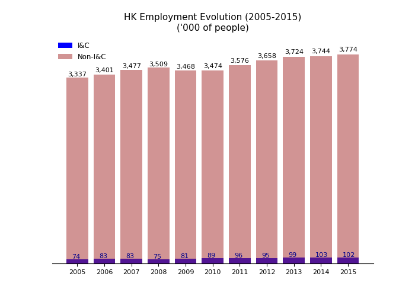

```python
xyears = range(2005,2016)


fig = plt.figure(figsize=(7,5))


# Subplot 1
ax = plt.gca()

p1 = ax.bar(xyears, full_data['HK I&C Employment'], color = 'blue')
p2 = ax.bar(xyears, full_data['HK Non-I&C Employment'], color = 'brown', alpha = 0.5)

plt.xticks(xyears, fontsize = 8)


ax.legend((p1[0], p2[0]), ('I&C', 'Non-I&C'), frameon = False, fontsize = 8.5)
ax.set_title("HK Employment Evolution (2005-2015)\n('000 of people)", fontsize = 11)

ax.yaxis.set_visible(False)
ax.spines['left'].set_visible(False)
ax.spines['top'].set_visible(False)
ax.spines['right'].set_visible(False)
ax.set_ylim(0,4000000);

for x, y in zip(xyears, full_data['HK Employed']):
    ax.annotate('{:,.0f}'.format(y/1000), xy = (x-.35,y-50000), fontsize = 8)

for x, y in zip(xyears, full_data['HK I&C Employment']):
    ax.annotate('{:,.0f}'.format(y/1000), xy = (x-.2,y+12000), color = 'darkblue', fontsize = 8)
```

### Chart 2

We then zoom into the I&C sector. We plot its population evolution, overlayed with the line charts for the changes in the overall population and the I&C sector population.

We notice two things:

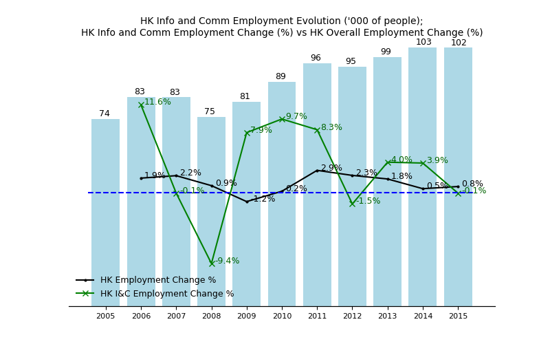

```python
fig = plt.figure(figsize=(8,5))

# Subplot 1
ax1 = fig.add_subplot(1,1,1)
ax1.bar(xyears, full_data['HK I&C Employment'], color = 'lightblue')

plt.sca(ax1)
plt.xticks(xyears, fontsize = 8)

ax1.set_title("HK Info and Comm Employment Evolution ('000 of people);\nHK Info and Comm Employment Change (%) vs HK Overall Employment Change (%)", fontsize = 10)

ax1.yaxis.set_visible(False)
ax1.spines['left'].set_visible(False)
ax1.spines['top'].set_visible(False)
ax1.spines['right'].set_visible(False)
ax1.set_ylim(0,105000);

for x, y in zip(xyears, full_data['HK I&C Employment']):
    ax1.annotate('{:.0f}'.format(y/1000), xy = (x-.2,y+1000), fontsize = 9)


# Subplot 2
ax2 = ax1.twinx()
ax2.plot(full_data['HK Employment Change %'], '-o', ms = 2, color = 'k')
ax2.plot(full_data['HK I&C Employment Change %'], '-x', color = 'green')

ax2.legend(loc = 3, fontsize = 9, frameon = False)

ax2.yaxis.set_visible(False)
ax2.spines['left'].set_visible(False)
ax2.spines['top'].set_visible(False)
ax2.spines['right'].set_visible(False)
ax2.set_ylim(-15,20)

for x, y in zip(xyears, full_data['HK Employment Change %']):
    ax2.annotate('{:.1f}%'.format(y), xy = (x+.1,y), color = 'k', fontsize = 9)

for x, y in zip(xyears, full_data['HK I&C Employment Change %']):
    ax2.annotate('{:.1f}%'.format(y), xy = (x+.1,y), color = 'darkgreen', fontsize = 9)

ax2.plot((2004.5,2015.5), (0,0), '--b');
```

### Chart 3

We compare the % of labour force engaged in the I&C sector in HK with that in Japan.

Although the I&C sector in HK is increasing in proportion, it is to an extent less significant than its counterpart in Japan. If the HK Government's goal is to promote HK as the regional hub of data center, they may find Japan, with its similar advantages in political environment and infrastructure, to be a substantial opponent.

Again we can see that in 2008 when the economic downturn was just starting, the I&C sector has quickly fallen to to its bottom. But the impact to the I&C sector was short-lived and the sector expanded soon after 2008.

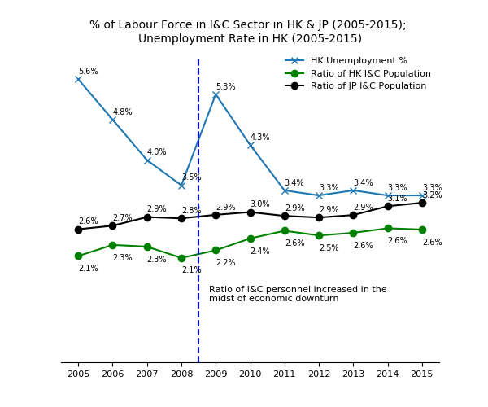

```python
fig = plt.figure(figsize=(6,5))


# Subplot 1
ax = plt.gca()

ax.plot(full_data['HK Unemployment %'], '-x')
ax.plot(full_data['Ratio of HK I&C Population'], '-og')
ax.plot(full_data['Ratio of JP I&C Population'], '-ok')

plt.xticks(xyears, fontsize = 8)

ax.set_title('% of Labour Force in I&C Sector in HK & JP (2005-2015); \nUnemployment Rate in HK (2005-2015)', fontsize = 10)
ax.yaxis.set_visible(False)
ax.spines['left'].set_visible(False)
ax.spines['top'].set_visible(False)
ax.spines['right'].set_visible(False)
ax.set_ylim(0,6.2)
ax.legend(loc=1, frameon = False, fontsize = 8)

for x, y in zip(xyears, full_data['Ratio of HK I&C Population']):
    ax.annotate('{:.1f}%'.format(y), xy=(x,y-0.3), textcoords = 'data', fontsize = 7)

for x, y in zip(xyears, full_data['Ratio of JP I&C Population']):
    ax.annotate('{:.1f}%'.format(y), xy=(x,y+0.1), textcoords = 'data', fontsize = 7)

# add annotation and line for 2008 economic downturn
plt.plot([2008.5, 2008.5], [0, 6], '--b')
ax.annotate('Ratio of I&C personnel increased in the \nmidst of economic downturn', xy=(2008.8, 1.2), fontsize = 8)



for x, y in zip(xyears, full_data['HK Unemployment %']):
    ax.annotate('{:}%'.format(y), xy = (x,y+.1), fontsize = 7)
```

### Chart 4

Then we have a simple demonstration of the evolution of average annual salary of an I&C sector employee.

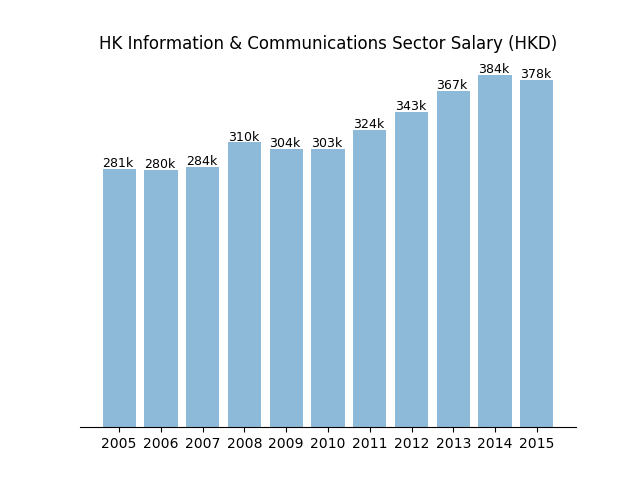

```python
fig = plt.figure()
plt.bar(xyears, full_data['HK I&C Employee Compensation (per head)'], alpha = 0.5)
plt.xticks(xyears)

ax = plt.gca()
ax.set_title('HK Information & Communications Sector Salary (HKD)')
ax.yaxis.set_visible(False)
ax.spines['left'].set_visible(False)
ax.spines['top'].set_visible(False)
ax.spines['right'].set_visible(False)

for x, y in zip(xyears, full_data['HK I&C Employee Compensation (per head)']):
    ax.annotate('{:.0f}k'.format(y/1000), xy=(x-.4,y+2000), textcoords = 'data', fontsize = 9)
```

```python
import numpy as np

salary_change = (full_data['HK I&C Employee Compensation (per head)'] - full_data['HK I&C Employee Compensation (per head)'].shift(1)) / full_data['HK I&C Employee Compensation (per head)'].shift(1) * 100
print('The compensation increase was rather robust through the period. However on rough estimation, the mean % increase is only {:.1f}%, which should be considered rather mild.'.format(np.mean(salary_change)))
```

```
The compensation increase was rather robust through the period. However on rough estimation, the mean % increase is only 3.1%, which should be considered rather mild.
```

# Conclusion

With the limitation of the data, we cannot easily draw robust conclusion from the data. What is clearly visible is that the importance of the Information and Communications industry, in terms of workforce, has been increasing. However the Hong Kong society still does not place much emphasis on this sector, visible from the volatility of employed population in the industry.

Also when compared with the counterpart sector in Japan, Hong Kong is still lagging behind even after the recent years of expansion in this industry. Without the proper support from the labour market, the Hon Kong Government's target to set up the city as the regional hub for data centers would not be easily reached.